# 4DN DamID - Ki67 project - Ki-67 ChIP-seq

Tom van Schaik

2022-02-10

### Project

Mapping of Ki67 interactions with the genome and comparison with lamina interactions.

### Introduction

Processing of Ki-67 ChIP-seq data, that we generated to determine whether we can (or can not) reproduce the pA-DamID results with an orthoganol methods. I already trimmed, mapped and counted the reads in 50kb bins. In this document, I will do the remaining processing:

- Counts-per-million normalization
- Log2-ratios of Ki-67 / input (* Quantile normalization) (* Optionally: smoothing)

I will write the data as .rds file, and prepare bigwig files.

### Method

See introduction.

### Set-up

Set the parameters and list the data.

```r
# Load dependencies - without warnings / messages
library(tidyverse)
library(GenomicRanges)
library(rtracklayer)
library(ggplot2)
library(preprocessCore) # quantile normalization

# Prepare output
output_dir <- "ts220210_further_processing_chipseq"
dir.create(output_dir, showWarnings = FALSE)


# Load input
chromosomes <- c(paste0("chr", 1:22), "chrX")


# Prepare seqnames
chrom_sizes <- read_tsv("~/mydata/data/genomes/GRCh38/hg38.chrom.sizes",
                        col_names = c("seqnames", "length"))
```

```r
library(knitr)
opts_chunk$set(fig.width = 5, fig.height = 3.5, cache = T,
               dev=c('png', 'pdf'),
               fig.path = file.path(output_dir, "figures/"))
pdf.options(useDingbats = FALSE)
```

### 1. Load counts

Load counts.

```r
# Read counts
counts <- read_tsv("ts220210_chipseq/deeptools/deeptools_bam_coverage.tab")
# Reformatting
counts <- counts %>%
  rename_at(1:3, ~ c("seqnames", "start", "end")) %>%
  rename_at(4:ncol(.), str_remove_all, "'") %>%
  mutate(start = start + 1) %>%
  filter(seqnames %in% chromosomes) %>%
  mutate(seqnames = factor(seqnames, levels = chromosomes)) %>%
  arrange(seqnames, start) %>%
  mutate(seqnames = as.character(seqnames))
```

### 2. Normalization

First, normalize to cpm. Also, bins < 10 reads are removed from further analyses.

```r
# Prepare metadata
samples <- names(counts)[4:ncol(counts)]

metadata <- tibble(sample = samples) %>%
  mutate(target = case_when(str_detect(sample, "antiGFP") ~ "GFP",
                            str_detect(sample, "antiKI67") ~ "Ki67",
                            T ~ "input"),
         timepoint = ifelse(str_detect(sample, "24h"),
                            "24h", "0h")) %>%
  mutate(target = factor(target, levels = c("input", "Ki67", "GFP")),
         timepoint = factor(timepoint, levels = c("0h", "24h"))) %>%
  mutate(experiment = paste("HCT116", target, timepoint, sep = "_"))

# Rename counts
counts <- counts %>%
  rename_at(4:ncol(.), ~ metadata$experiment)

# Normalize to cpm
cpm <- function(x, min_count = 0) {
  # Normalize vector to cpm (total count: 1M)
  x_cpm <- x / sum(x) * 1e6
  x_cpm[x < min_count] <- NA

  x_cpm
}

counts_norm <- counts %>%
  mutate_at(all_of(unique(metadata$experiment)), cpm)


# Finally, remove values for rows with too few reads (in absolute numbers)
min_reads <- 10

idx_not_enough_reads <- counts %>%
  dplyr::select(4:ncol(.)) %>%
  mutate_all(function(x) x >= min_reads) %>%
  mutate(sum = rowSums(.),
         idx = sum <= 3) %>%
  pull(idx)

counts_norm[idx_not_enough_reads, 4:ncol(counts_norm)] <- NA
```

```r
# Log2-ratio
norm <- counts_norm %>%
  mutate(
    HCT116_Ki67_0h =
      log2((HCT116_Ki67_0h + 1) /
             (HCT116_input_0h + 1)),
    HCT116_Ki67_24h =
      log2((HCT116_Ki67_24h + 1) /
             (HCT116_input_24h + 1)),
    HCT116_GFP_0h =
      log2((HCT116_GFP_0h + 1) /
             (HCT116_input_0h + 1)),
    HCT116_GFP_24h =
      log2((HCT116_GFP_24h + 1) /
             (HCT116_input_24h + 1))) %>%
  dplyr::select(-contains("input"))

# Quantile normalization
norm_quant <- norm
norm_quant[, 4:ncol(norm_quant)] <- norm_quant %>%
  dplyr::select(4:ncol(.)) %>%
  as.matrix() %>%
  normalize.quantiles(.)
norm_quant <- norm_quant %>%
  rename_at(4:ncol(.), function(x) paste0(x, "_quant"))
```

I also want to determine the difference between the time points. Maybe the difference would give me something that is most comparable with our “real” Ki-67 interaction data.

```r
norm_diff <- norm %>%
  mutate(HCT116_Ki67_0h = HCT116_Ki67_0h - HCT116_Ki67_24h,
         HCT116_GFP_0h = HCT116_GFP_0h - HCT116_GFP_24h) %>%
  dplyr::select(-contains("24h")) %>%
  rename_at(4:ncol(.), function(x) paste0(x, "_diff"))
```

Finally, get the mean between the replicates to use in downstream analyses.

However, there are no replicates (yet).

```r
# Average between replicates
norm_average <- norm_quant %>%
  rowwise() %>%
  mutate(
    HCT116_no_iaa =
      mean(c(HCT116_no_iaa_early_r1,
             HCT116_no_iaa_early_r2),
           na.rm = T),
    HCT116_iaa =
      mean(c(HCT116_iaa_early_r1,
             HCT116_iaa_early_r2),
           na.rm = T)
  ) %>%
  ungroup() %>%
  dplyr::select(-contains("_r"))
```

### 3. Create bigwigs

Finally, create bigwigs of the (quantile) normalized tracks.

```r
# Function
ExportBWFromTibble <- function(tib, bigwig_dir, column = "diff", name = NULL) {

  # Set name as column
  if (is.null(name)) name <- column

  # Get GRanges from Tibble
  gr <- tib %>%
    dplyr::select(1:3, all_of(column)) %>%
    drop_na() %>%
    dplyr::rename_at(4, ~ "score") %>%
    as(., "GRanges")

  # Exception: LADs and SPIN states
  if (grepl("LAD", column)) {
    gr$score <- ifelse(gr$score == "LAD", 1, 0)
  }

  if (grepl("SPIN", column)) {
    return(NULL)
  }

  # Add chromosome information
  seqlengths(gr) <- chrom_sizes$length[match(seqlevels(gr),
                                             chrom_sizes$seqnames)]

  # Write bigwig
  export.bw(object = gr,
            con = file.path(bigwig_dir, paste0(name, ".bw")))

}

BWsFromTibble <- function(tib) {
  invisible(lapply(names(tib)[4:ncol(tib)],
                   function(sample) {
                     ExportBWFromTibble(tib,
                                        bigwig_dir = bigwig_dir,
                                        column = sample)
                   }
  ))
}

# Prepare bigwigs - normalized
bigwig_dir <- file.path(output_dir, "bigwig")
dir.create(bigwig_dir, showWarnings = F)

BWsFromTibble(norm)
BWsFromTibble(norm_quant)
BWsFromTibble(norm_diff)

# Prepare bigwigs - counts
bigwig_dir <- file.path(output_dir, "bigwig_counts")
dir.create(bigwig_dir, showWarnings = F)

BWsFromTibble(counts_norm)
```

### 4. Plots

I want to make some plots that compare time points and antibodies.

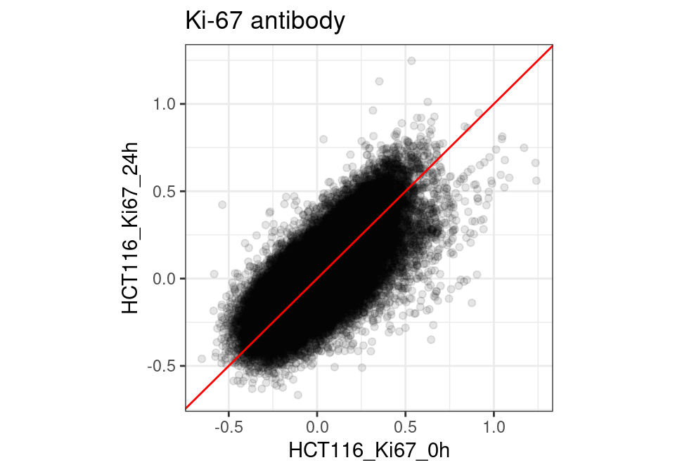

```r
# Correlation between time points
norm %>%
  ggplot(aes(x = HCT116_Ki67_0h, y = HCT116_Ki67_24h)) +
  geom_point(alpha = 0.1) +
  geom_abline(intercept = 0, slope = 1, col = "red") +
  ggtitle("Ki-67 antibody") +
  theme_bw() +
  theme(aspect.ratio = 1)
```

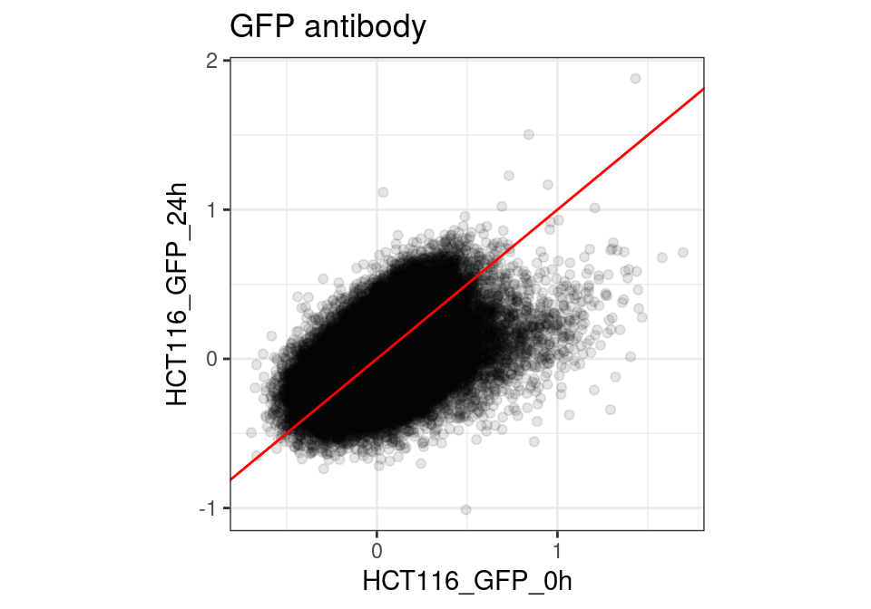

```r
norm %>%
  ggplot(aes(x = HCT116_GFP_0h, y = HCT116_GFP_24h)) +
  geom_point(alpha = 0.1) +
  geom_abline(intercept = 0, slope = 1, col = "red") +
  ggtitle("GFP antibody") +
  theme_bw() +
  theme(aspect.ratio = 1)
```

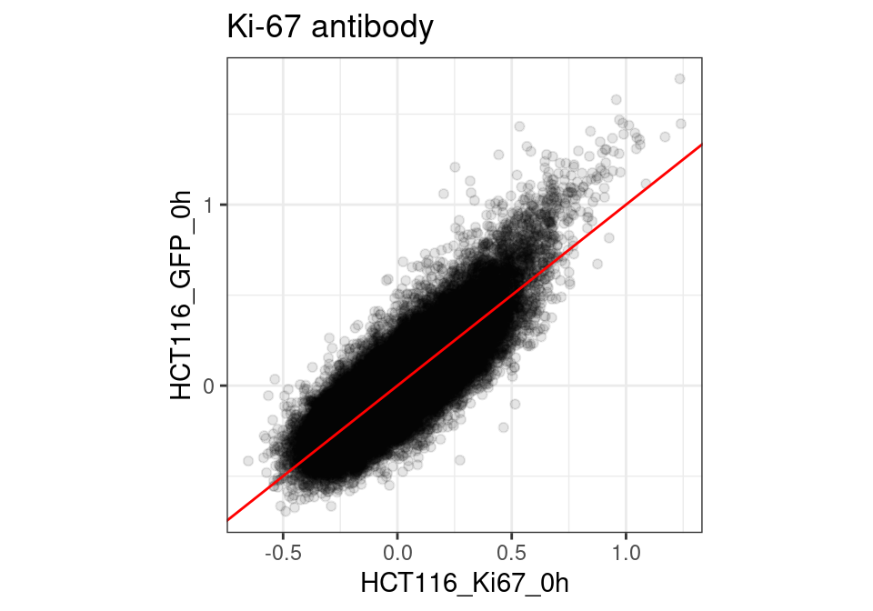

```r
# Correlation between antibody
norm %>%
  ggplot(aes(x = HCT116_Ki67_0h, y = HCT116_GFP_0h)) +
  geom_point(alpha = 0.1) +
  geom_abline(intercept = 0, slope = 1, col = "red") +
  ggtitle("Ki-67 antibody") +
  theme_bw() +
  theme(aspect.ratio = 1)
```

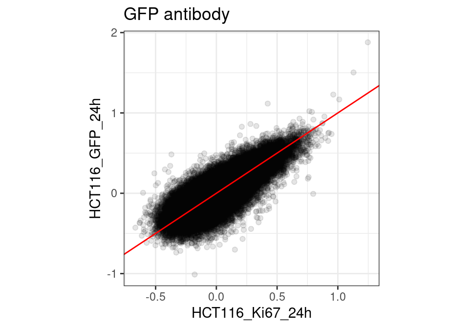

```r
norm %>%
  ggplot(aes(x = HCT116_Ki67_24h, y = HCT116_GFP_24h)) +
  geom_point(alpha = 0.1) +
  geom_abline(intercept = 0, slope = 1, col = "red") +
  ggtitle("GFP antibody") +
  theme_bw() +
  theme(aspect.ratio = 1)
```

### Conclusions

```r
# Save RDS files of the ranges
saveRDS(norm, file.path(output_dir, "tib_norm.rds"))
saveRDS(norm_quant, file.path(output_dir, "tib_norm_quant.rds"))
saveRDS(norm_diff, file.path(output_dir, "tib_norm_diff.rds"))
saveRDS(metadata, file.path(output_dir, "tib_repliseq_metadata.rds"))
```